# 1.2.Graphing with R

Adapted from Software Carpentry; modified by Maina,Stephanie

27 October 2017

### **Before starting**

**We need data to play with:**

```r
data <- read.csv("data/seed_root_herbivores.csv", as.is=TRUE)  # Read the csv file:
```

**What have we got here?**

```r
head(data)
```

```
##     Plot Seed.herbivore Root.herbivore No.stems Height Weight Seed.heads
## 1 plot-2           TRUE           TRUE        1     31   4.16         83
## 2 plot-2           TRUE           TRUE        3     41   5.82        175
## 3 plot-2           TRUE           TRUE        1     42   3.51         72
## 4 plot-2           TRUE          FALSE        1     64   7.16        125
## 5 plot-2           TRUE          FALSE        1     47   6.17        212
## 6 plot-2           TRUE          FALSE        1     52   5.32        114
##   Seeds.in.25.heads
## 1                 7
## 2                 0
## 3                32
## 4                22
## 5                 3
## 6                19
```

- Different ways reference columns, should all work

```r
data[,"Height"]
data[["Height"]]
data$Height
```

### **1. Histograms**

```r
? hist()
```

**Plot histogram of height**

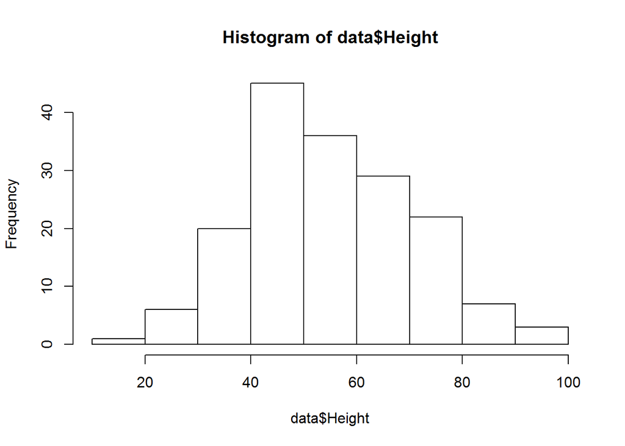

```r
hist(data$Height)
```

**Lets add better axis labels**

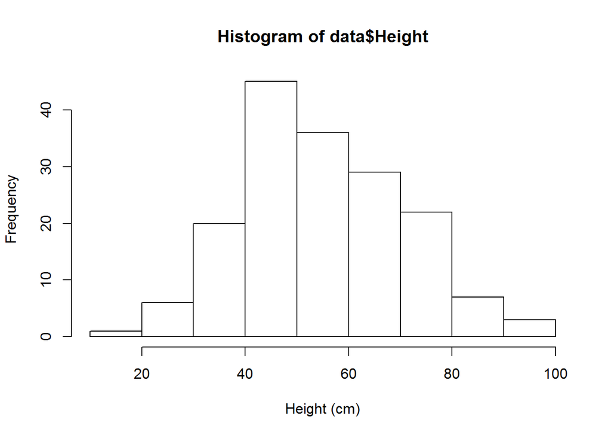

```r
hist(data$Height, xlab='Height (cm)')
```

**Lets colour our columns & add main title**

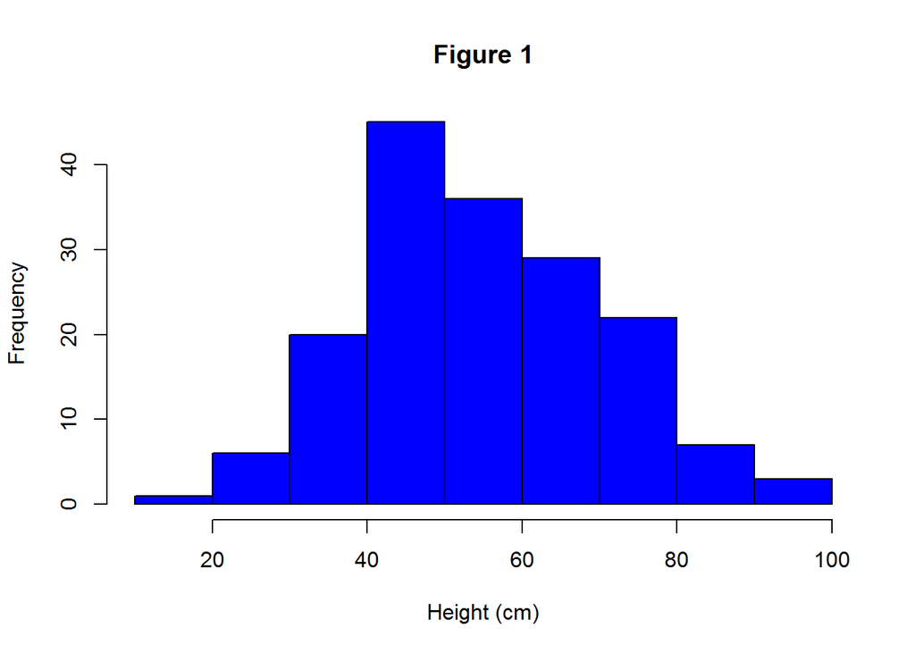

```r
hist(data$Height, xlab='Height (cm)', col='blue', main="Figure 1")
```

**Another way to specify colours**

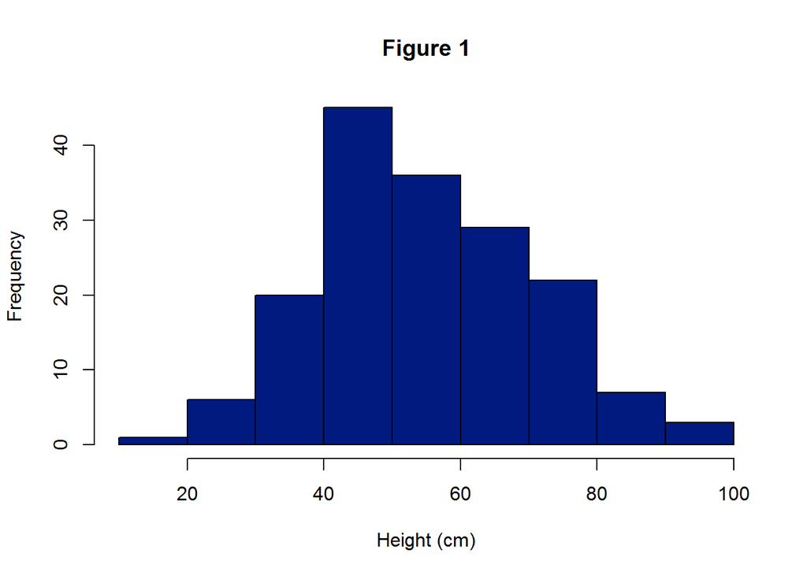

```r
hist(data$Height, xlab="Height (cm)", col=rgb(0,0.1,0.5), main="Figure 1")
```

**Make a histogram for seed.heads… with no axes or labels**

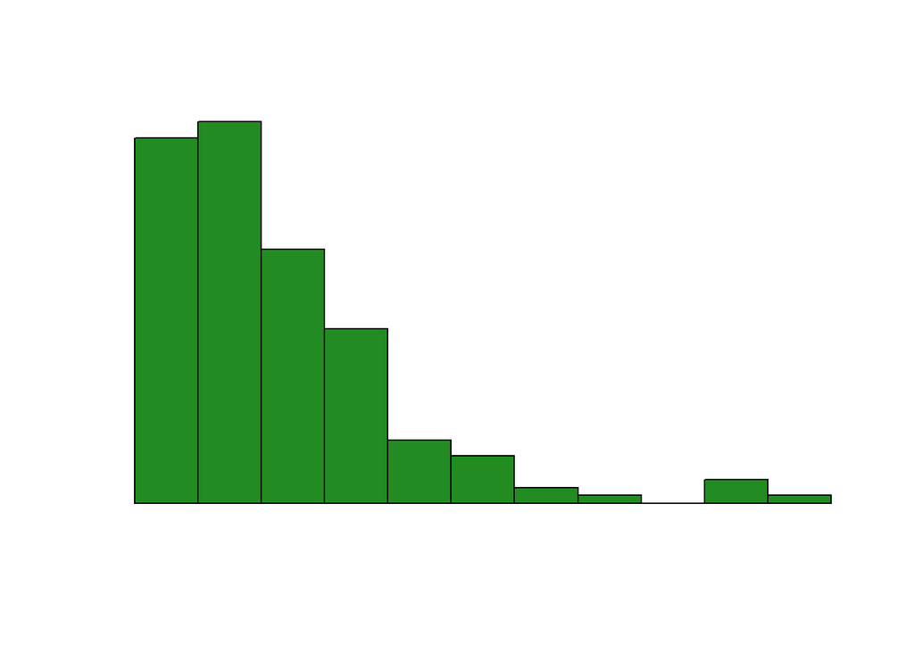

```r
hist(data$Seed.heads, col='forestgreen', ann=FALSE, axes=FALSE)
```

**Add axes manually (allows for greater control)**

```r
?axis()
```

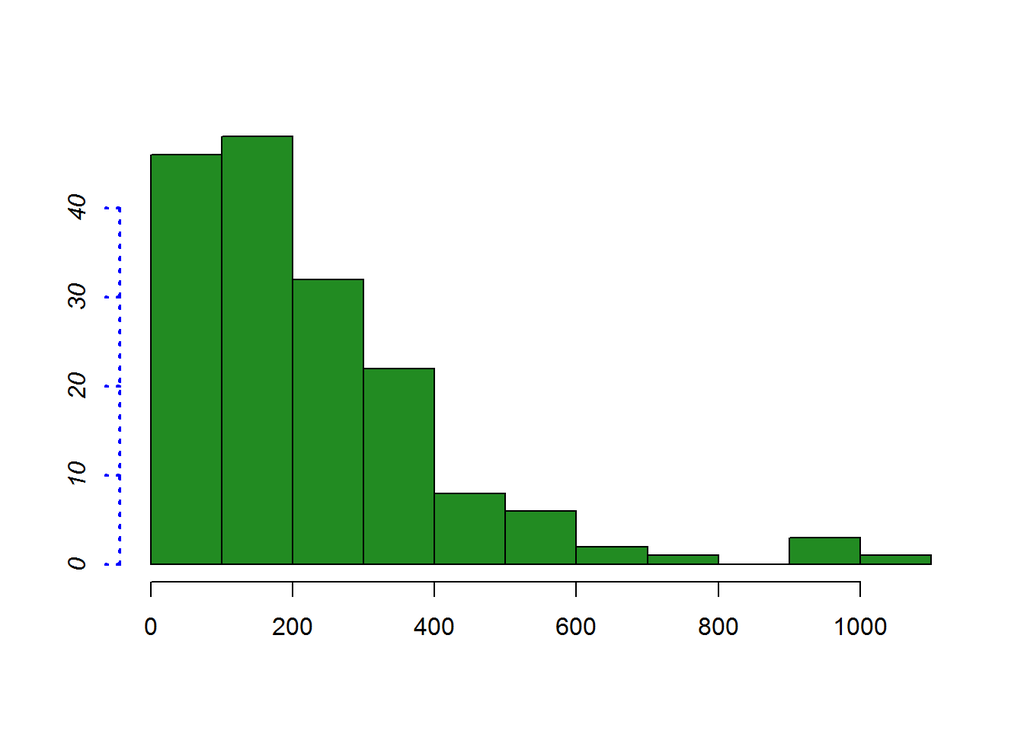

```r
hist(data$Seed.heads, col='forestgreen', ann=FALSE, axes=FALSE)
axis(side= 1)   # identical to what would have been drawn from hist()
axis(2, lwd=2, lty=3, col='blue', font=3)   # specify details of line
```

**Another way to add margin text (aka - label)**

```r
?mtext()
```

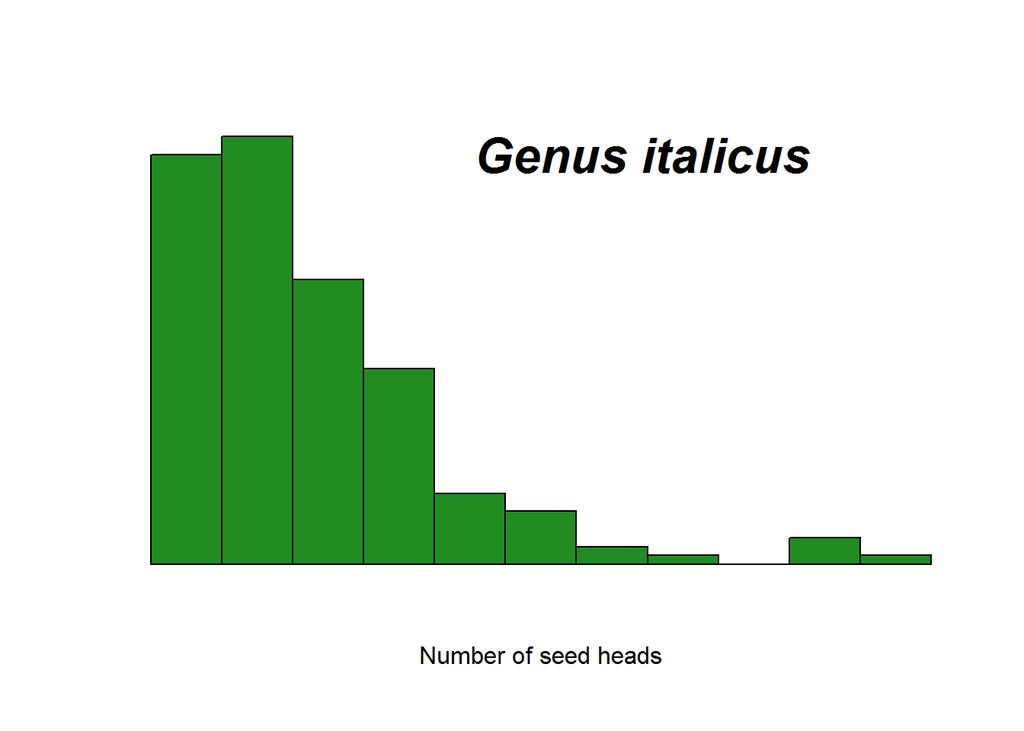

```r
hist(data$Seed.heads, col='forestgreen', ann=FALSE, axes=FALSE)
mtext("Genus italicus", side=3, line=-2, font=4, adj=0.7, cex=2)    # big, italic font right side
mtext("Number of seed heads", side=1, line=2)
```

**What other options does histogram have?**

```r
? hist()
```

- **Set “breaks”**

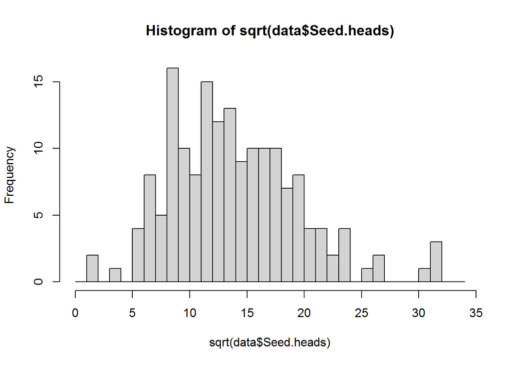

```r
hist(sqrt(data$Seed.heads), breaks=(0:34), col='lightgrey')
```

**What else can “hist()” DO?**

```r
seedHeadHist <- hist(sqrt(data$Seed.heads), breaks=(0:36), plot=FALSE)
seedHeadHist
```

```
## $breaks
##  [1]  0  1  2  3  4  5  6  7  8  9 10 11 12 13 14 15 16 17 18 19 20 21 22
## [24] 23 24 25 26 27 28 29 30 31 32 33 34 35 36
##
## $counts
##  [1]  0  2  0  1  0  4  8  5 16 10  8 15 12 13  9 10 10 10  7  8  4  4  2
## [24]  4  0  1  2  0  0  0  1  3  0  0  0  0
##
## $density
##  [1] 0.00000000 0.01183432 0.00000000 0.00591716 0.00000000 0.02366864
##  [7] 0.04733728 0.02958580 0.09467456 0.05917160 0.04733728 0.08875740
## [13] 0.07100592 0.07692308 0.05325444 0.05917160 0.05917160 0.05917160
## [19] 0.04142012 0.04733728 0.02366864 0.02366864 0.01183432 0.02366864
## [25] 0.00000000 0.00591716 0.01183432 0.00000000 0.00000000 0.00000000
## [31] 0.00591716 0.01775148 0.00000000 0.00000000 0.00000000 0.00000000
##
## $mids
##  [1]  0.5  1.5  2.5  3.5  4.5  5.5  6.5  7.5  8.5  9.5 10.5 11.5 12.5 13.5
## [15] 14.5 15.5 16.5 17.5 18.5 19.5 20.5 21.5 22.5 23.5 24.5 25.5 26.5 27.5
## [29] 28.5 29.5 30.5 31.5 32.5 33.5 34.5 35.5
##
## $xname
## [1] "sqrt(data$Seed.heads)"
##
## $equidist
## [1] TRUE
##
## attr(,"class")
## [1] "histogram"
```

### **2. Bivariate plots**

```r
?plot()
```

**Specify the column with the x data and the column with the y data**

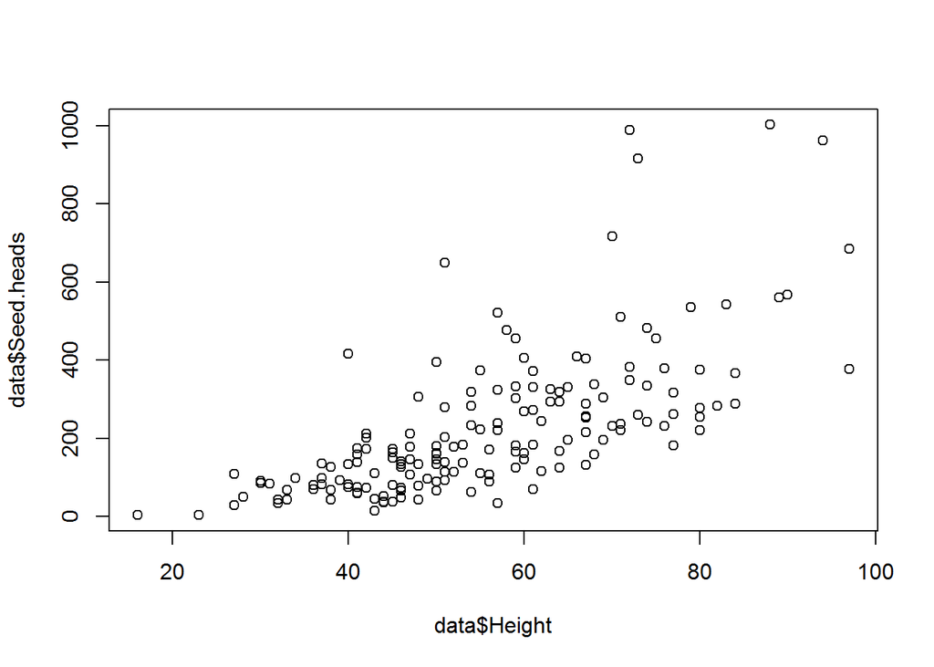

```r
plot(data$Height, data$Seed.heads)
```

**Alternatively, use formula notation (same plot, but better default axis labels)**

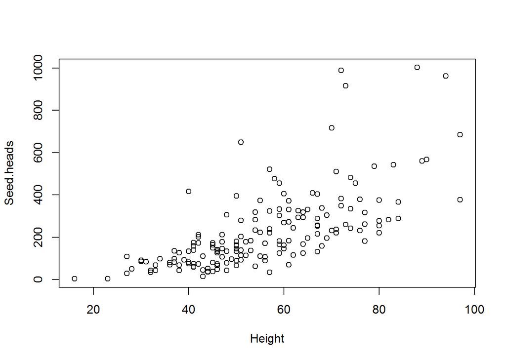

```r
plot(Seed.heads ~ Height, data)
```

**Plot it with a square root transform on the y axis?**

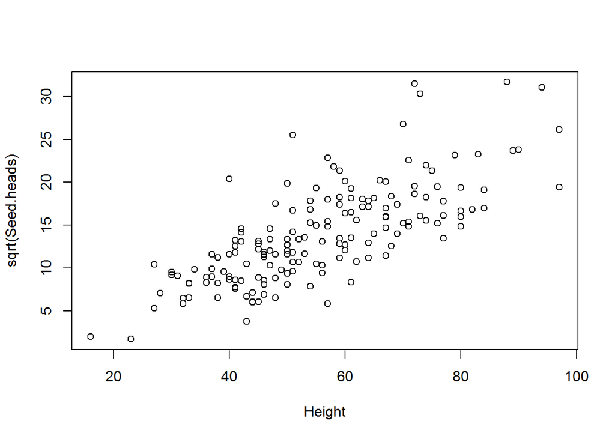

```r
plot(sqrt(Seed.heads) ~ Height, data)
```

**Lets make nicer axis labels**

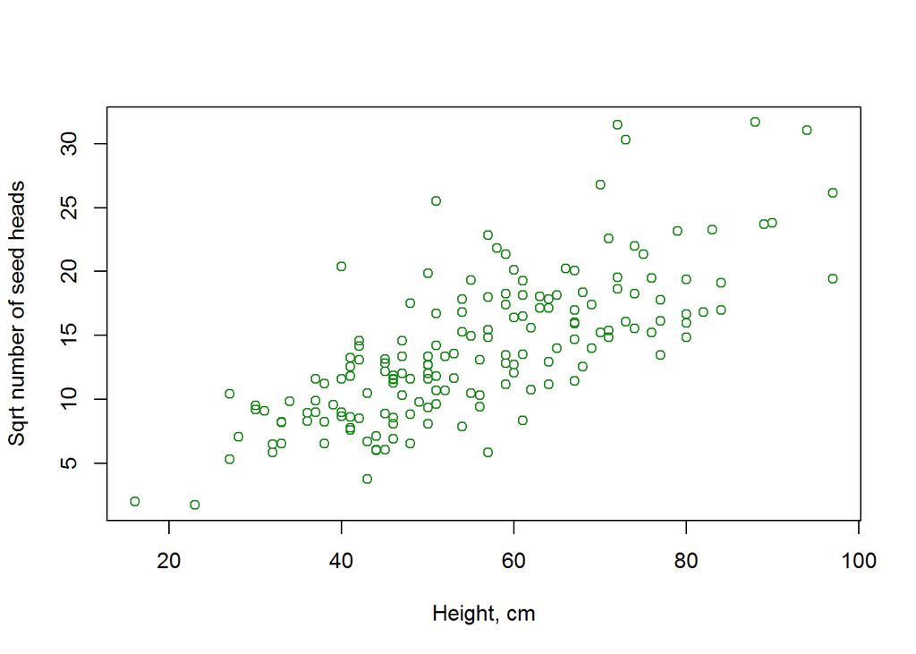

```r
plot(sqrt(Seed.heads) ~ Height, data, xlab="Height, cm", ylab="Sqrt number of seed heads", col='forestgreen')
```

**Lets make it plot lines instead**

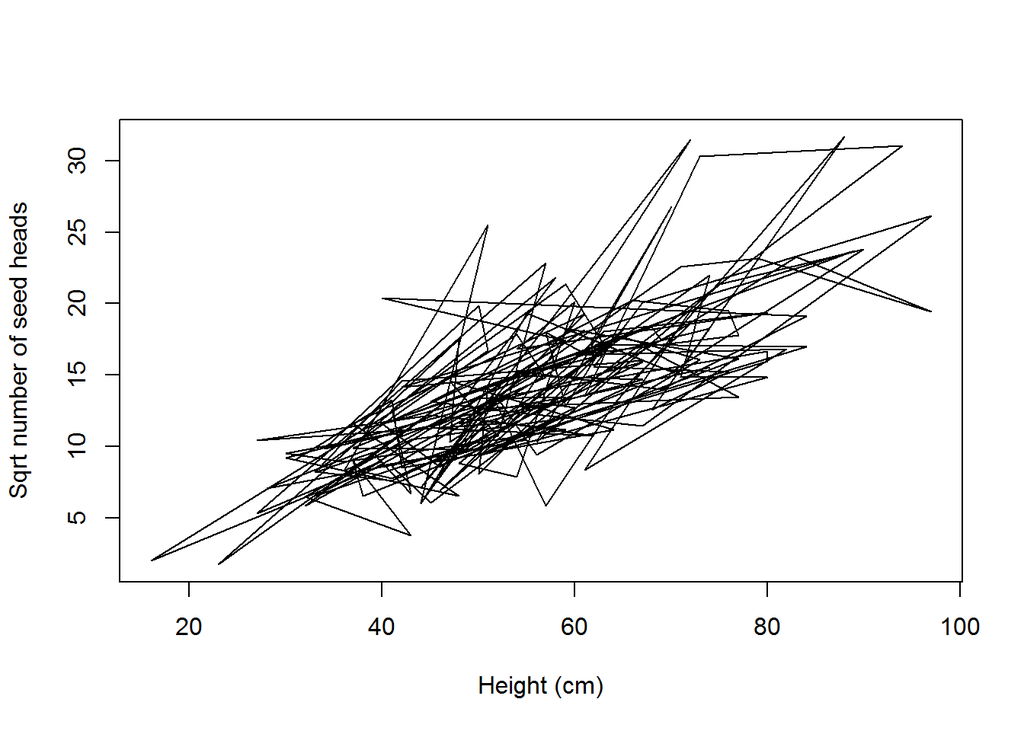

```r
plot(sqrt(Seed.heads) ~ Height, data, xlab="Height (cm)", ylab="Sqrt number of seed heads", type = "l")
```

**Lets make it plot the axes, but not any points!**

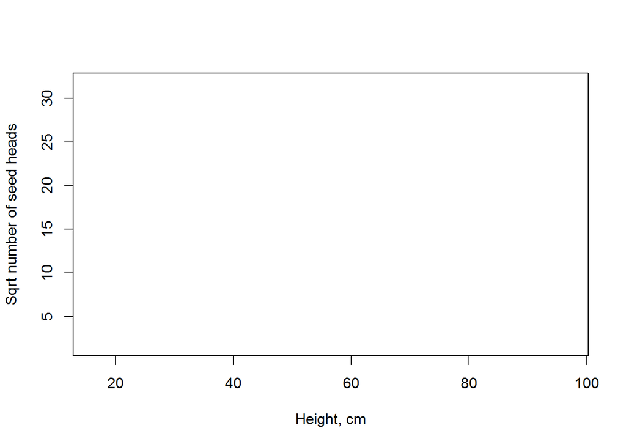

```r
plot(sqrt(Seed.heads) ~ Height, data, xlab="Height, cm", ylab="Sqrt number of seed heads", type="n")
```

**?? Why would we want to do that??**

```r
?points()
```

**Lets plot the `"Root.herbivore == TRUE"` treatment as red circles**

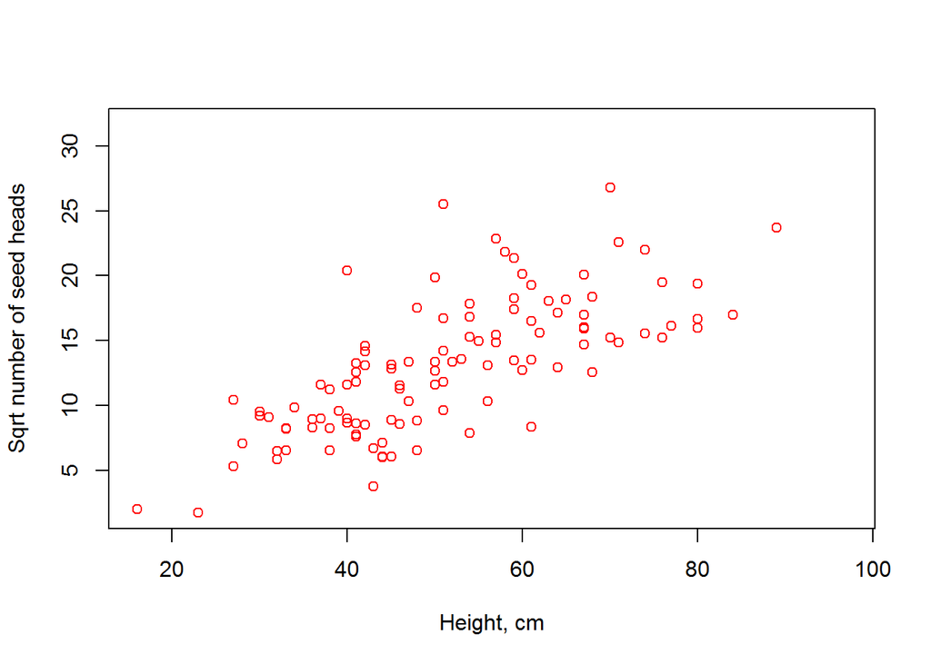

```r
plot(sqrt(Seed.heads) ~ Height, data, xlab="Height, cm", ylab="Sqrt number of seed heads", type="n")
points(sqrt(Seed.heads) ~ Height, data=data[data$Root.herbivore==TRUE,], col="red", pch=21)
```

**Lets plot the `"Root.herbivore == FALSE"` treatment as green squares**

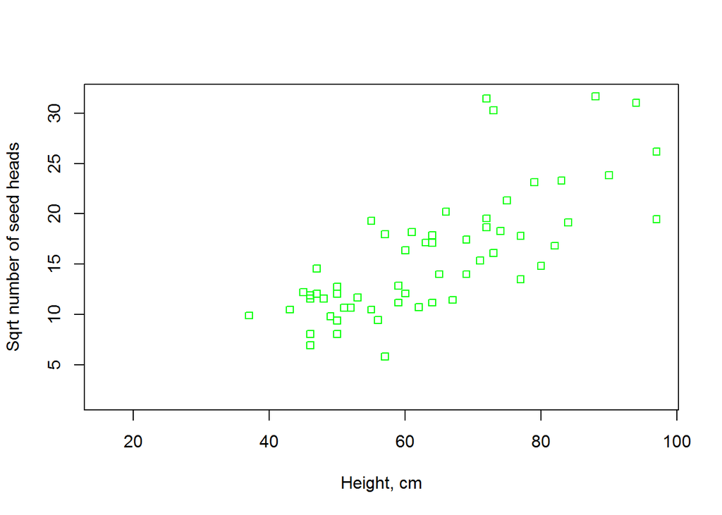

```r
plot(sqrt(Seed.heads) ~ Height, data, xlab="Height, cm", ylab="Sqrt number of seed heads", type="n")
points(sqrt(Seed.heads) ~ Height, data=data[data$Root.herbivore==FALSE,], col="green", pch=22)
```

**What else can we specify for points?**

Plot is super general (it will try to plot anything).. here it defaults to points, factors default to boxplots…

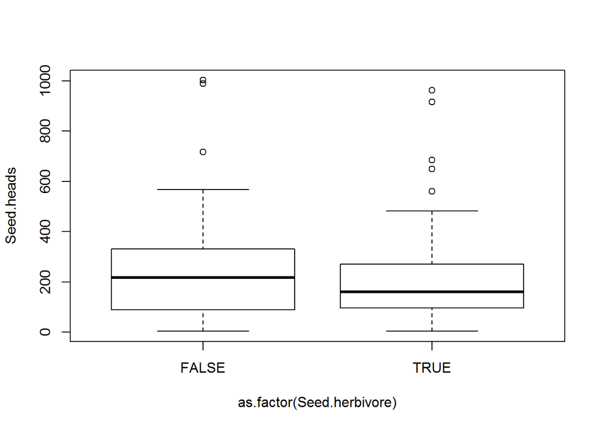

```r
plot(Seed.heads ~ as.factor(Seed.herbivore), data)
```

### **3. Box plots**

```r
?boxplot()
```

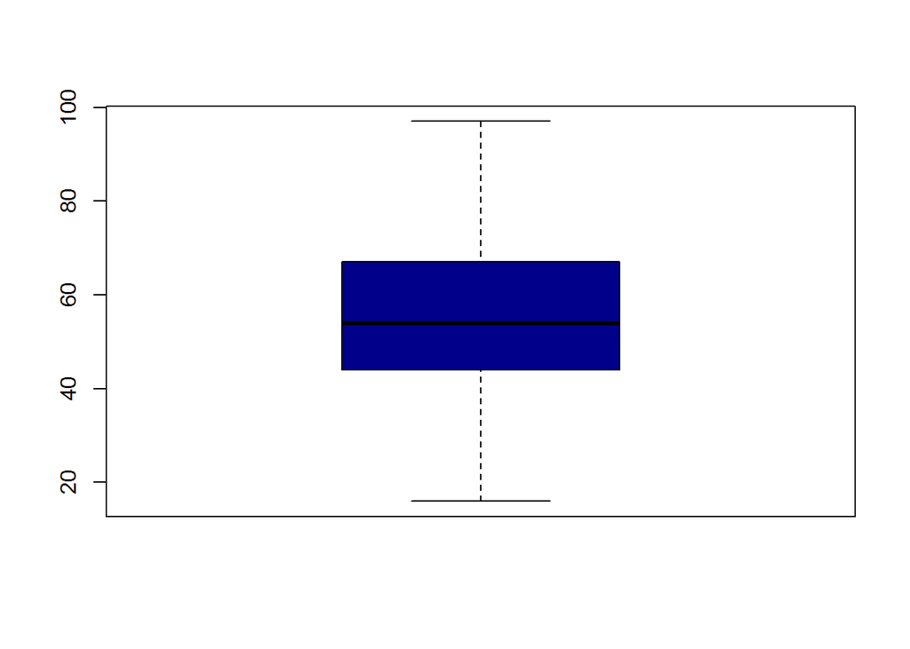

```r
boxplot(data$Height, col='darkblue')
```

**SPLIT IT BY “Root.herbivore” TREATMENT?**

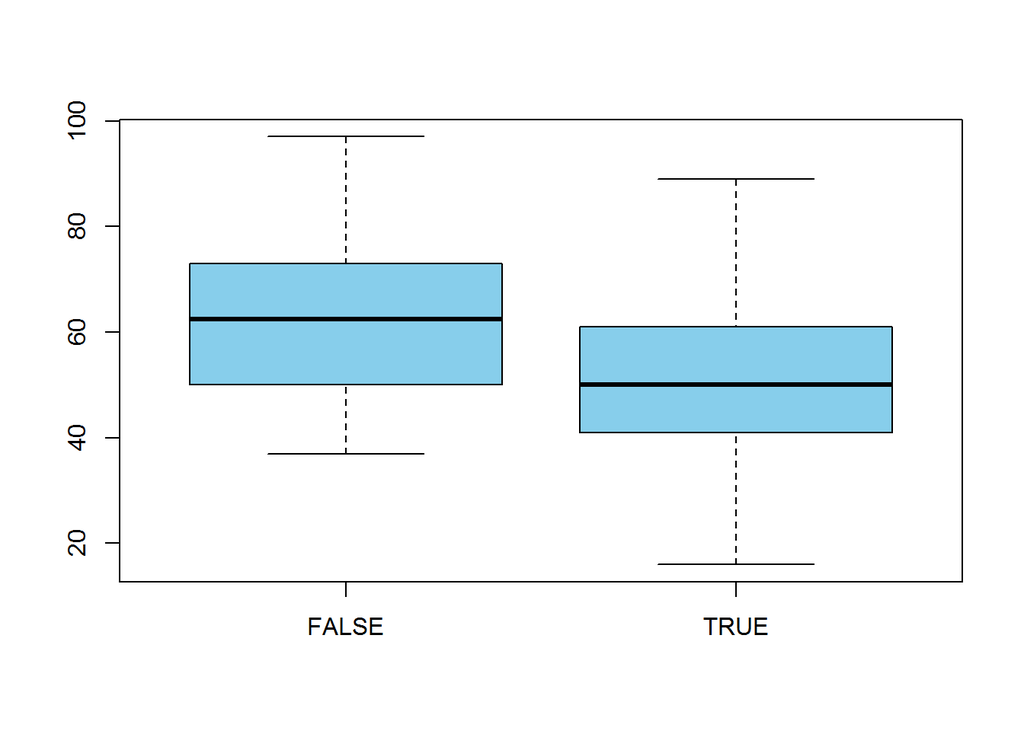

```r
boxplot(Height ~ Root.herbivore, data, col='skyblue')
```

**Better axis labels**

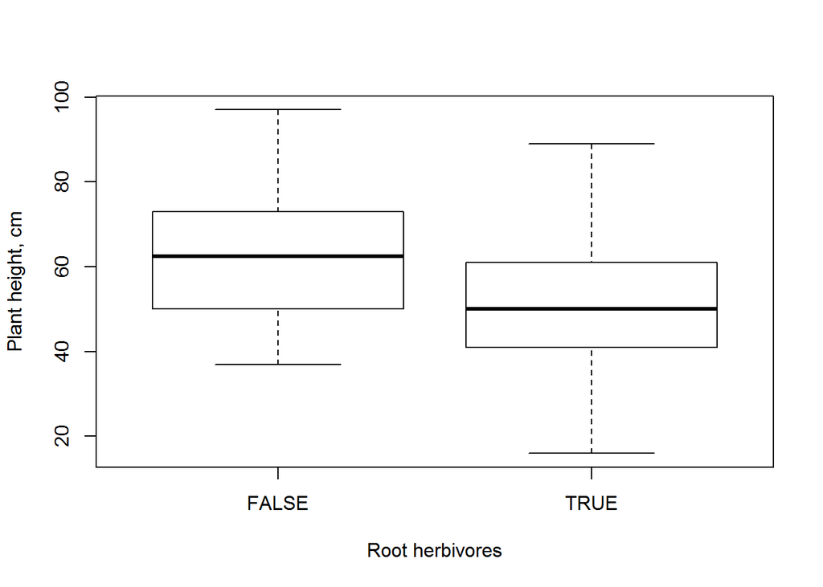

```r
boxplot(Height ~ Root.herbivore, data, xlab="Root herbivores", ylab="Plant height, cm")
```

**Add `"notch"` es?**

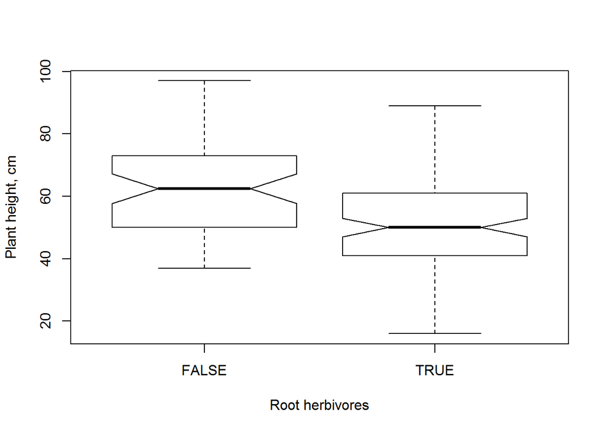

```r
boxplot(Height ~ Root.herbivore, data, xlab="Root herbivores", ylab="Plant height, cm", notch = TRUE)
```

**?? What are the “notches??**

Overlay the points? ( it works - if we make `root.herbivore` a factor )

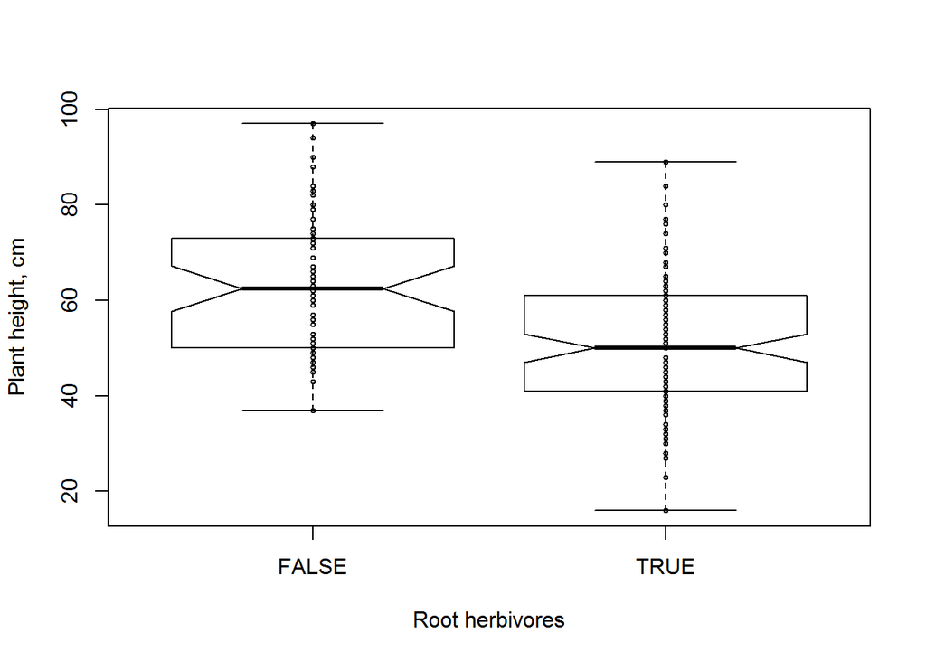

```r
boxplot(Height ~ Root.herbivore, data, xlab="Root herbivores", ylab="Plant height, cm", notch = TRUE)
points(as.factor(data$Root.herbivore),data$Height, cex=0.5)
```

### **4.Exploratory plotting**

```r
?pairs()
```

A very cool fucntion, but only works with numeric data. A Great way to quickly access collinearity among variables.

```r
pairs(data)
```

```
## Error in pairs.default(data): non-numeric argument to 'pairs'
```

**Which columns have numeric data??**

```r
names(data)
```

```
## [1] "Plot"              "Seed.herbivore"    "Root.herbivore"
## [4] "No.stems"          "Height"            "Weight"
## [7] "Seed.heads"        "Seeds.in.25.heads"
```

```r
comps <- names(data)[2:8]
comps
```

```
## [1] "Seed.herbivore"    "Root.herbivore"    "No.stems"
## [4] "Height"            "Weight"            "Seed.heads"
## [7] "Seeds.in.25.heads"
```

**Behold a quick set of plots for all pair-wise comparisons**

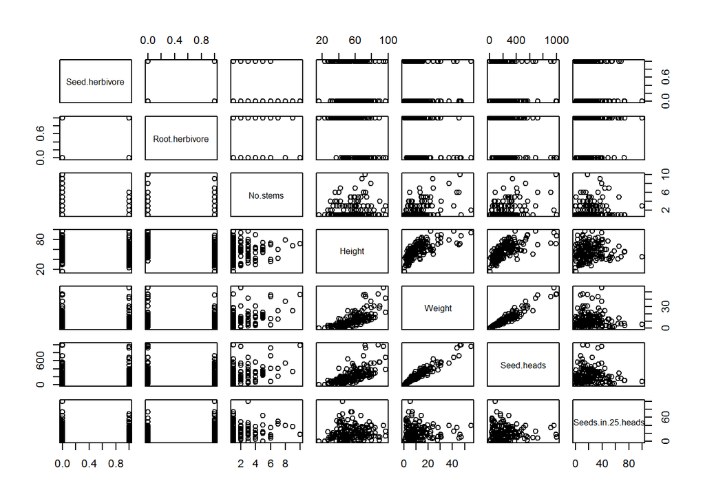

```r
pairs(data[comps])
```

### **5. 3D plotting**

**Lets use the built in volcano dataset for this…**

```r
?volcano
```

**Two good built in functions are `image()` and `contour()`**

```r
image(volcano)
contour(volcano)
```

**Specify the colour gradient**

```r
image(volcano, col=terrain.colors(50))
```

**Add" contours over top of `image()`**

```r
contour(volcano, add=TRUE)
```

### **6. Bar plots**

I personally really dislike barplots, but they are commonly used. R does not have a standard error function, but we can write one…

```r
standard.error <- function(x) { sd(x)/sqrt(length(x)) }
```

Remember all the way back to the morning…

USE `"aggregate"` TO GET THE mean `data['Height']`

BY `data[c("Root.herbivore", "Seed.herbivore")]`

- **TIP**: USING `data["Height"]` INSTEAD OF `data$Height` GIVES YOU NICER COLUMN NAMES

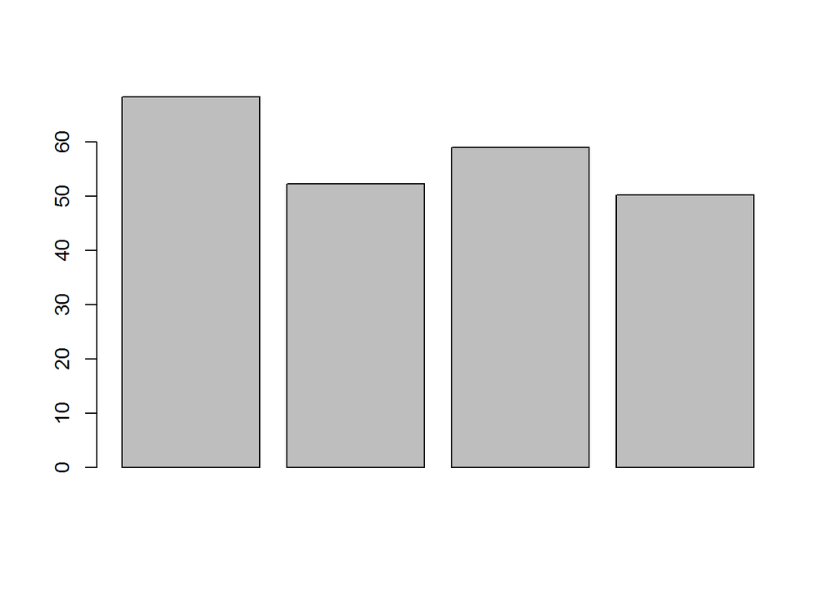

```r
mn <- aggregate(data["Height"], data[c("Root.herbivore", "Seed.herbivore")], mean)
bp <- barplot(mn$Height)
```

** USE `"aggregate"` TO GET THE standard.error**

```r
se <- aggregate(data["Height"], data[c("Root.herbivore", "Seed.herbivore")], standard.error)
```

** Add the standard error using arrows**

```r
arrows(bp, mn$Height + se$Height, bp, mn$Height - se$Height, code=3, angle=90)
```

*Note: by assigning barplot() to bp… we can do the next step*

?? Doesn’t quite look right

**Make a bar plot and specify y-axis “ylim” so that the whole se fits in…**

```r
bp <- barplot(mn$Height, ylim=c(0, max(mn$Height + se$Height)))
arrows(bp, mn$Height + se$Height, bp, mn$Height - se$Height, code=3, angle=90)
```

**Add labels**

```r
axis(1, at=bp, labels=as.character(mn$Root.herbivore))
axis(1, at=bp, labels=as.character(mn$Seed.herbivore), line=1, tick=FALSE)
```

? What does `tick` do?

**Make better labels**

```r
herb_labels <- c("None", "Root only", "Seed only", "Both root & seed")
bp <- barplot(mn$Height, ylim=c(0, 80))
arrows(bp, mn$Height + se$Height, bp, mn$Height - se$Height, code=3, angle=90)
axis(1, at=bp, labels=herb_labels)
```

Still not what we want because r does skips labels that would over write

```r
axis(1, at=bp, labels=herb_labels, las=2)
title("Barplots are a pain...")
```

*How do we fix the margin size…*

*Show me how to do that crazy voodoo that youdoo?*

*Remember if you dig deep enough you can tinker with anything in r*

*Afraid? “You will be. You… will… be.” (Yoda)*

## **7. Global graphic parameters**

```r
?par
```

- **NOTE**: No one remembers all of these parameters but hopefully you will remember that ?par gets you the answer
- **NOTE**: Closing your graphing window will reset your global parameters (for good and bad)
- **TIP**: You can save parameters to a variable to restore your old ones
- **TIP**: par() Will tell you what the current parameters are

**Save current / original parameters**

```r
oldPar <- par()
```

So how can we fix our margin issue?

```r
par(mar=c(9, 4, 4, 2))
bp <- barplot(mn$Height, ylim=c(0, 80))
arrows(bp, mn$Height + se$Height, bp, mn$Height - se$Height, code=3, angle=90, lwd=2)
axis(1, at=bp, labels=herb_labels, las=2)
mtext("Type of herbivory", side=1, line=7)
mtext("Plant height, cm", side=2, line=3)
title("Barplots are still a pain...")
```

**Restore original parameters**

```r
par(oldPar)
```

### **8. Saving plots**

- **NOTE**: You can save or “export” the graphing window to save your plots
- **TIP**: Don’t save or “export” the graphing window to save your plots
- **TIP**: Always use a vector format (i.e., pdf) so that your plots look good when scaled
- **TIP**: If you must use a raster format use png rather than jpeg
- **TIP**: Save your plot from the command line! - Total control of plot sizes, etc to meet specific journal requirements - You can just run a script to regenerate all your plots if (when) your data change or your supervisor wants it to look a little different - Everytime the script runs you will always get the exact same plot, reproducibility is key to good science
- **TIP**: Make a subdirectory called “figs” in your project directory dir.create(“./figs”)
- **NOTE**: Fancy script - only creates the directory if the directory is not already there
- **TIP**: Dealing with the unexpected well is what makes flexible code (most code we write it not flexible) if(!(“./figs”) %in% list.dirs(“.”)) dir.create(“./figs”)

**Start a pdf file to write to:**

```r
par(mar=c(9, 4, 4, 2))
bp <- barplot(mn$Height, ylim=c(0, 80))
arrows(bp, mn$Height + se$Height, bp, mn$Height - se$Height, code=3, angle=90, lwd=2)
axis(1, at=bp, labels=herb_labels, las=2)
mtext("Type of herbivory", side=1, line=7)
mtext("Plant height, cm", side=2, line=3)
title("Barplots are still a pain...")
pdf("./figs/my_barplot.pdf", width=5, height=5)
```

What are the units of width and height?

Must always use `dev.off()` when you are done writing to the file… or it stays open…

```r
par(mar=c(9, 4, 4, 2))
bp <- barplot(mn$Height, ylim=c(0, 80))
arrows(bp, mn$Heigh + se$Height, bp, mn$Heigh - se$Height, angle=90, code=3)
axis(1, at=bp, labels=herb_labels, las=2)
mtext("Degree of herbivory", 1, line=7)
mtext("Plant height, cm", 2, line=3)
title("Barplots are a pain...")
dev.off()
```

**Start a png file**

```r
png(filename="./figs/my_barplot2.png", width=400, height=400)
par(mar=c(9, 4, 4, 2))
bp <- barplot(mn$Height, ylim=c(0, 80))
arrows(bp, mn$Heigh + se$Height, bp, mn$Heigh - se$Height, angle=90, code=3)
axis(1, at=bp, labels=herb_labels, las=2)
mtext("Degree of herbivory", 1, line=7)
mtext("Plant height, cm", 2, line=3)
title("Barplots are a pain...")
dev.off()
```

- **TIP**: When things go wrong saving plots - It is nearly always because the file was not closed - Repeat dev.off() until it says “cannot shut down device”

### **9. Multiple panel plots**

`"mfrow"` Fills your panels across the top row and then sequential rows down

`"mfcol"` Fills your panels down the left most column first…

```r
oldPar <- par()
```

**Make 4 histograms**

```r
par(mfcol=c(2,2))
hist(data$Height, col='blue')
hist(data$Height, col='green')
hist(data$Height, col='red')
hist(data$Height)
par(oldPar)
```

**Lets make it nicer…**

```
+ Set margins all to 1

+ Set the outer margins to `c(4,3,4,2)`
```

```r
par(mfrow=c(2, 2), mar=c(1, 1, 1, 1), oma=c(4, 3, 4, 2))
#lets only put the outer axes on (common if the axes are the same)
#lets label each panel a-d in the upper left corner
hist(data$Height, ann=FALSE, axes=FALSE, col='forestgreen')
axis(2)
mtext("A", 3, -2, adj = 0.1, font=2, cex=1.2)
hist(data$Height, ann=FALSE, axes=FALSE, col='darkblue')
mtext("B", 3, -2, adj = 0, font=2, cex=1.2)
hist(data$Height, ann=FALSE, col='skyblue')
mtext("C", 3, -2, adj = 0.1, font=2, cex=1.2)
hist(data$Height, ann=FALSE, axes=FALSE, col='grey40')
axis(1)
mtext("D", 3, -2, adj = 0, font=2, cex=1.2)
```

Just to demonstrate the possible boxes…

```r
?box()
box("plot", col="red")
box("figure", col="blue")
box("inner", col="black")
box("outer", col="pink")
##  `mtext` really shines - putting joint axis labels  `"outer"`
mtext("Height (cm)", side=1, outer=TRUE, line=2)
mtext("Frequency", side=2, outer=TRUE, line=2)
mtext("Four plots of height", side=3, outer=TRUE, line=1, cex=1.5)
```

### **10.Adding additional things to plots**

```r
plot(sqrt(Seed.heads) ~ Height, data, type="p", axes=FALSE, ann=FALSE, pch=21, col="white", bg="black")
axis(1)
axis(2, las=2)
mtext("Height (cm)", side = 1, line = 3)
mtext("sqrt(Number of seed heads)", side = 2, line = 3)
title("Figure 1", adj=0)
```

**Get/Plot a best fit line using `lm()`**

```r
mod <- lm(sqrt(Seed.heads) ~ Height, data)
```

**Plot the line using `abline`**

```r
abline(mod, lwd=2, lty=2, col='blue')
```

**Get/plot the prediction intervals**

```r
hs <- seq(min(data$Height), max(data$Height), 1)
seed_pred <- predict(mod, list(Height = hs), interval = "prediction")
lines(hs, seed_pred[,"lwr"], lty = 2)
lines(hs, seed_pred[,"upr"], lty = 2)
```

**Plot a shaded confidence interval region**

```r
polygon(c(hs, rev(hs)), c(seed_conf[,"lwr"], rev(seed_conf[,"upr"])), col = rgb(0,0,0,0.2), border = NA)
```

**Let’s add the r-squared to the plot**

- **TIP**: Unicode characters are an easy way to get some characters

```r
text(80,5,paste("r\U00b2 = ",round(summary(mod)$r.squared,2))) # mod_sqrt does not exist: change to mod
```

**Add a legend**

```r
legend("topleft", c("green data", "actual data", "orange point"), pch=c(4, 20, 3), col=c("green", "black", "orange"), bty="n")
```

Add some math

```r
text(90, 3, expression(Y[i] == beta[0]+beta[1]*X[i1]+epsilon[i])) # see demo(plotmath) for more examples
```

Now… Wrap the super nice plots into a pdf…

```r
dev.off()
```